# Sprawozdanie - Zadanie 3

## 4.2 Wykresy rozkładów średnich czasów odpowiedzi

### 4.2.1 Rozkład średniego czasu rozwiązywania zadań z Nauk Przyrodniczych

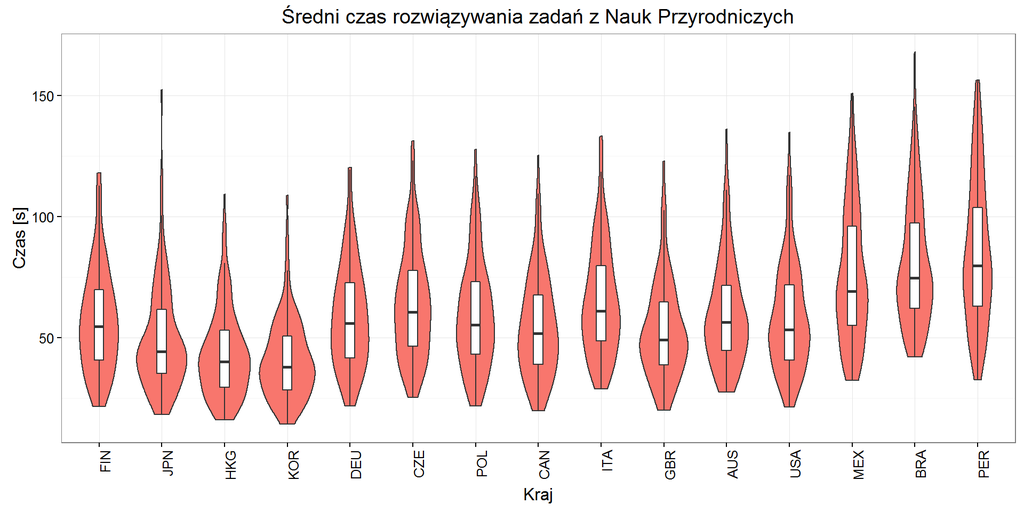

### 4.2.2 Rozkład średniego czasu rozwiązywania zadań z Czytania ze Zrozumieniem

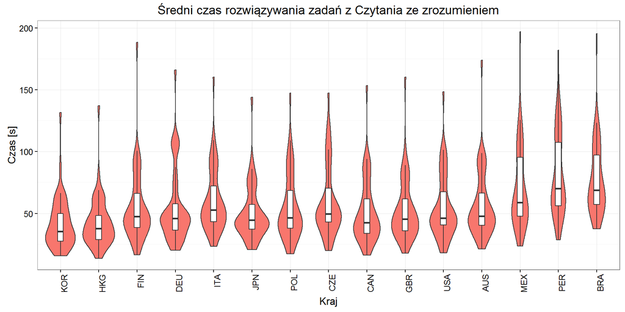

### 4.2.3 Rozkład średniego czasu rozwiązywania zadań z Matematyki

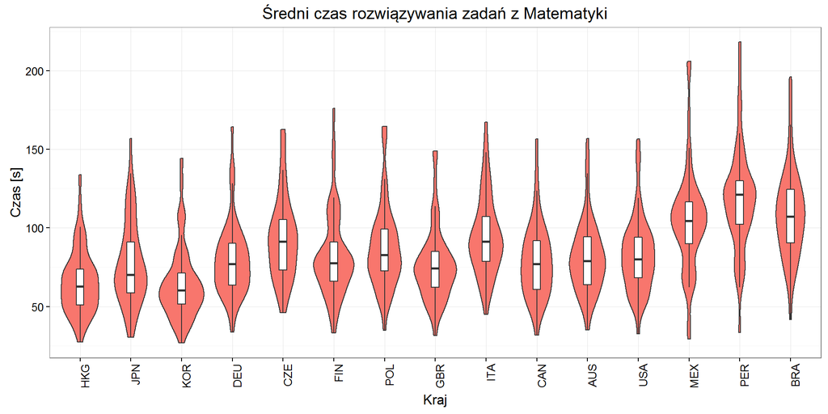

## 4.3 Wykresy zależności dla płci

Na pierwszym wykresie poniżej widać, że zwykle dziewczynki dłużej rozwiązywały zadania z matematyki i przyrody niż chłopcy (punkty w większości pod pomocniczą prostą). Ciekawy jest jednak fakt, że wbrew stereotypom, czas poświęcony na rozwiązywanie zadań z czytania jest w zasadzie równy dla obu płci dzieci.

Z drugiego wykresu widzimy, że dla zadań z matematyki i przyrody chłopcy osiągają więcej dobrych wyników niż dziewczynki. Natomiast zadania z czytania lepiej rozwiązują dziewczynki.

Wyniki dla Polski (zaznaczone większym punktem) w obu przypadkach odpowiadają ogólnym wnioskom.

### 4.3.1 Średni czas rozwiązywania zadań chłopcy vs. dziewczynki z uwzględnieniem kraju

[interactive chart not shown]

### 4.3.2 Procent dobrych odpowiedzi chłopcy vs. dziewczynki z uwzględnieniem kraju

[interactive chart not shown]

# 5. Wykonany kod

```r
library("tidyr")
library("dplyr")
library("ggplot2")
library("plotly")
library("openxlsx")
library("matrixStats")
library("knitr")
library("stringr")
library("stringi")

load("finalS.RData")

finalS$result<-ifelse(finalS$result=="No credit", 0, ifelse(finalS$result=="Partial credit", 1,2))
finalS<-finalS %>% mutate(timing=timing/1000)

statSR<-finalS %>% group_by(item_short, CNT,result) %>%
  summarize(Ile=n())%>% spread(result,Ile) %>% as.data.frame()

statS<-finalS %>% group_by(item_short, CNT) %>%
  summarize(minScore=min(result),
            medScore_W=weightedMedian(result,W_FSTUWT),
            medScore=median(result),
            meanScore=round(weighted.mean(result, W_FSTUWT),2),
            maxScore=max(result),
            minActions=min(n.actions),
            medActions=median(n.actions),
            meanActions=round(weighted.mean(n.actions, W_FSTUWT),2),
            maxActions=max(n.actions),
            minTiming=min(timing),
            medTiming_W=weightedMedian(timing,W_FSTUWT),
            medTiming=median(timing),
            meanTiming=round(weighted.mean(timing, W_FSTUWT),2),
            maxTiming=max(timing)) %>% as.data.frame()
statScience<-merge(statS, statSR, by=c("item_short", "CNT"), all.x=TRUE)


f<-unique(statScience$item_short)
lista<-vector("list", length(f))
for (i in 1:length(f)){
  lista[[i]]<- statScience[which(statScience$item_short==f[i]),-1]
}
names(lista)<-as.character(f)
write.xlsx(lista, file = "statystyki_Science.xlsx")


finalMR$result<-ifelse(finalMR$result=="No credit", 0, ifelse(finalMR$result=="Partial credit", 1,2))
finalMR <- finalMR %>% mutate(timing=timing/1000)
statR<-finalMR %>% group_by(item_short, CNT) %>%
  summarize(minScore=min(result),
            medScore_W=weightedMedian(result,W_FSTUWT),
            medScore=median(result),
            meanScore=round(weighted.mean(result, W_FSTUWT),2),
            maxScore=max(result),
            minActions=min(n.actions),
            medActions=median(n.actions),
            meanActions=round(weighted.mean(n.actions, W_FSTUWT),2),
            maxActions=max(n.actions),
            minTiming=min(timing),
            medTiming_W=weightedMedian(timing,W_FSTUWT),
            medTiming=median(timing),
            meanTiming=round(weighted.mean(timing, W_FSTUWT),2),
            maxTiming=max(timing)) %>% filter(str_detect(item_short,'R'))%>% as.data.frame()

statMRR<-finalMR %>% group_by(item_short, CNT,result) %>%
  summarize(Ile=n())%>% spread(result,Ile) %>% as.data.frame()

statReading<-merge(statR, statMRR, by=c("item_short", "CNT"), all.x=TRUE)
f<-unique(statReading$item_short)
lista<-vector("list", length(f))
for (i in 1:length(f)){
  lista[[i]]<- statReading[which(statReading$item_short==f[i]),-1]
}
names(lista)<-as.character(f)
write.xlsx(lista, file = "statystyki_Reading.xlsx")

statM<-finalMR %>% group_by(item_short, CNT) %>%
  summarize(minScore=min(result),
            medScore_W=weightedMedian(result,W_FSTUWT),
            medScore=median(result),
            meanScore=round(weighted.mean(result, W_FSTUWT),2),
            maxScore=max(result),
            minActions=min(n.actions),
            medActions=median(n.actions),
            meanActions=round(weighted.mean(n.actions, W_FSTUWT),2),
            maxActions=max(n.actions),
            minTiming=min(timing),
            medTiming_W=weightedMedian(timing,W_FSTUWT),
            medTiming=median(timing),
            meanTiming=round(weighted.mean(timing, W_FSTUWT),2),
            maxTiming=max(timing)) %>% filter(str_detect(item_short,'M'))%>% as.data.frame()

statMath<-merge(statM, statMRR, by=c("item_short", "CNT"), all.x=TRUE)

f<-unique(statMath$item_short)
lista<-vector("list", length(f))
for (i in 1:length(f)){
  lista[[i]]<- statMath[which(statMath$item_short==f[i]),-1]
}
names(lista)<-as.character(f)
write.xlsx(lista, file = "statystyki_Math.xlsx")


statSR<-statSR  %>%mutate_if(is.factor, as.character)

statSR$proportion<-(ifelse(is.na(statSR$`2`),0,statSR$`2`) + ifelse(is.na(statSR$`1`),0,statSR$`1`))/(ifelse(is.na(statSR$`2`),0,statSR$`2`) + ifelse(is.na(statSR$`1`),0,statSR$`1`)+statSR$`0`)
rank<-statSR %>% group_by(CNT) %>% summarise(medProp=median(proportion))

rank<-rank[order(rank$medProp, decreasing = T),]

rank2<-rank%>%mutate(CNT=stri_trim(CNT))%>%filter(CNT %in% c("POL", "GBR", "FIN", "DEU", "HKG", "JPN", "KOR", "USA", "MEX", "PER", "BRA", "CAN", "AUS", "ITA","CZE") )
statS2<-statS%>% mutate_if(is.factor, as.character) %>%mutate(CNT=stri_trim(CNT)) %>%filter(CNT %in% c("POL", "GBR", "FIN", "DEU", "HKG", "JPN", "KOR", "USA", "MEX", "PER", "BRA", "CAN", "AUS", "ITA","CZE") )

ggplot(statS2, aes(x=factor(CNT, levels=rank2$CNT), y=meanTiming))+geom_violin(aes(fill="#3366FF"),scale = "count")+geom_boxplot(width = 0.2,outlier.shape = NA)+xlab("Kraj")+ylab("Czas [s]")+theme_bw()+
  theme(axis.text.x = element_text(angle = 90, hjust = 1))+  ggtitle("Średni czas rozwiązywania zadań z Nauk Przyrodniczych")+guides(fill=FALSE, color=FALSE)


statMRR<-statMRR %>%mutate_if(is.factor, as.character)
statMRR$proportion<-(ifelse(is.na(statMRR$`2`),0,statMRR$`2`) + ifelse(is.na(statMRR$`1`),0,statMRR$`1`))/(ifelse(is.na(statMRR$`2`),0,statMRR$`2`) + ifelse(is.na(statMRR$`1`),0,statMRR$`1`)+statMRR$`0`)
rankR<-statMRR %>% group_by(CNT)%>% filter(str_detect(item_short,'R')) %>% summarise(medProp=median(proportion))
rankR<-rankR[order(rankR$medProp, decreasing = T),]
rankR2<-rankR%>% mutate(CNT=stri_trim(CNT)) %>% filter(CNT %in% c("POL", "GBR", "FIN", "DEU", "HKG", "JPN", "KOR", "USA", "MEX", "PER", "BRA", "CAN", "AUS", "ITA","CZE") )
statR2<-statR%>% mutate(CNT=stri_trim(CNT)) %>%filter(CNT %in% c("POL", "GBR", "FIN", "DEU", "HKG", "JPN", "KOR", "USA", "MEX", "PER", "BRA", "CAN", "AUS", "ITA","CZE") )

ggplot(statR2, aes(x=factor(CNT, levels=rankR2$CNT), y=meanTiming))+geom_violin(aes(fill="#3366FF"),scale = "count")+geom_boxplot(width = 0.2,outlier.shape = NA)+xlab("Kraj")+ylab("Czas [s]")+theme_bw()+
  theme(axis.text.x = element_text(angle = 90, hjust = 1))+  ggtitle("Średni czas rozwiązywania zadań z Czytania ze Zrozumieniem")+guides(fill=FALSE, color=FALSE)


rankM<-statMRR %>% group_by(CNT)%>% filter(str_detect(item_short,'M')) %>% summarise(medProp=median(proportion))
rankM<-rankM[order(rankM$medProp, decreasing = T),]
rankM2<-rankM%>% mutate(CNT=stri_trim(CNT)) %>% filter(CNT %in% c("POL", "GBR", "FIN", "DEU", "HKG", "JPN", "KOR", "USA", "MEX", "PER", "BRA", "CAN", "AUS", "ITA","CZE") )
statM2<-statM%>% mutate(CNT=stri_trim(CNT)) %>%filter(CNT %in% c("POL", "GBR", "FIN", "DEU", "HKG", "JPN", "KOR", "USA", "MEX", "PER", "BRA", "CAN", "AUS", "ITA","CZE") )

save(statM2, file="statM2.RData")

ggplot(statM2, aes(x=factor(CNT, levels=rankM2$CNT), y=meanTiming))+geom_violin(aes(fill="#3366FF"),scale = "count")+geom_boxplot(width = 0.2,outlier.shape = NA)+xlab("Kraj")+ylab("Czas [s]")+theme_bw()+
  theme(axis.text.x = element_text(angle = 90, hjust = 1))+  ggtitle("Średni czas rozwiązywania zadań z Matematyki")+guides(fill=FALSE, color=FALSE)

statM_all_sex<-finalMR %>% filter(str_detect(item_short,'M')) %>% group_by(CNT,ST004D01T) %>%
  summarize(sredniaT=round(weighted.mean(timing, W_FSTUWT),2)) %>% spread(ST004D01T,sredniaT)   %>% mutate(form="M")
statM_all_sex$CNT<-stri_trim(as.character(statM_all_sex$CNT))

statR_all_sex<-finalMR %>% filter(str_detect(item_short,'R')) %>% group_by(CNT,ST004D01T) %>%
  summarize(sredniaT=round(weighted.mean(timing, W_FSTUWT),2)) %>% spread(ST004D01T,sredniaT)  %>%  mutate(form="R")
statR_all_sex$CNT<-stri_trim(as.character(statR_all_sex$CNT))

statS_all_sex<-finalS %>% group_by(CNT,ST004D01T) %>%
  summarize(sredniaT=round(weighted.mean(timing, W_FSTUWT),2))%>% spread(ST004D01T,sredniaT)   %>% mutate(form="S")
statS_all_sex$CNT<-stri_trim(as.character(statS_all_sex$CNT))

stat_sex<-rbind(statM_all_sex,statR_all_sex,statS_all_sex)
stat_sex<-stat_sex %>% mutate(if_POL=ifelse(CNT=="POL",1,0))

write.xlsx(stat_sex, file="stat_sex.xlsx")
save(stat_sex, file="stat_sex.RData")

g<-ggplot(stat_sex, aes(Female, Male , colour=form, size=if_POL, text =paste("Kraj:", CNT)))+
  geom_point()+
  geom_abline()+
  coord_fixed() +
  ggtitle("Średni czas rozwiązywania zadań \nchłopcy vs. dziewczynki z uwzględnieniem kraju")+
  guides(fill=FALSE, color=FALSE, shape=FALSE, size=FALSE)+
  scale_y_continuous(labels=c(paste(40,"s"), paste(60,"s"), paste(80,"s"), paste(100,"s"), paste(120,"s")),limits=c(40,120))+
  scale_x_continuous(labels=c(paste(40,"s"), paste(60,"s"), paste(80,"s"), paste(100,"s"), paste(120,"s")),limits=c(40,120))

g %>% ggplotly(originalData = FALSE,tooltip=c("text", "Female", "Male"), legend=FALSE)

statM_all_sex_prop<-finalMR %>% filter(str_detect(item_short,'M')) %>% group_by(CNT,ST004D01T, result) %>% summarize(Ile=n())%>% spread(result,Ile) %>% as.data.frame()

statR_all_sex_prop<-finalMR %>% filter(str_detect(item_short,'R')) %>% group_by(CNT,ST004D01T, result) %>% summarize(Ile=n())%>% spread(result,Ile) %>% as.data.frame()

statS_all_sex_prop<-finalS %>% group_by(CNT,ST004D01T, result) %>% summarize(Ile=n())%>% spread(result,Ile) %>% as.data.frame()

statM_all_sex_prop$proportion<-100*round((statM_all_sex_prop$`2` + ifelse(is.na(statM_all_sex_prop$`1`),0,statM_all_sex_prop$`1`))/(statM_all_sex_prop$`2` + ifelse(is.na(statM_all_sex_prop$`1`),0,statM_all_sex_prop$`1`)+statM_all_sex_prop$`0`),4)
statM_all_sex_prop<-statM_all_sex_prop[,c(1,2,6)] %>% spread(ST004D01T,proportion)  %>%  mutate_if(is.factor, as.character) %>% mutate(CNT=stri_trim(CNT)) %>%mutate(form="M", if_POL=ifelse(CNT=="POL",1,0)) %>%as.data.frame()

statR_all_sex_prop$proportion<-100*round((statR_all_sex_prop$`2` + ifelse(is.na(statR_all_sex_prop$`1`),0,statR_all_sex_prop$`1`))/(statR_all_sex_prop$`2` + ifelse(is.na(statR_all_sex_prop$`1`),0,statR_all_sex_prop$`1`)+statR_all_sex_prop$`0`),4)
statR_all_sex_prop<-statR_all_sex_prop[,c(1,2,6)] %>% spread(ST004D01T,proportion)  %>%  mutate_if(is.factor, as.character) %>% mutate(CNT=stri_trim(CNT)) %>% mutate(form="R", if_POL=ifelse(CNT=="POL",1,0)) %>%as.data.frame()

statS_all_sex_prop$proportion<-100*round((statS_all_sex_prop$`2` + ifelse(is.na(statS_all_sex_prop$`1`),0,statS_all_sex_prop$`1`))/(statS_all_sex_prop$`2` + ifelse(is.na(statS_all_sex_prop$`1`),0,statS_all_sex_prop$`1`)+statS_all_sex_prop$`0`),4)
statS_all_sex_prop<-statS_all_sex_prop[,c(1,2,6)] %>% spread(ST004D01T,proportion)  %>%  mutate_if(is.factor, as.character) %>% mutate(CNT=stri_trim(CNT)) %>% mutate(form="S", if_POL=ifelse(CNT=="POL",1,0)) %>%as.data.frame()

stat_sex_prop<-rbind(statM_all_sex_prop, statR_all_sex_prop, statS_all_sex_prop)
write.xlsx(stat_sex_prop, file="stat_sex_prop.xlsx")
save(stat_sex_prop, file="stat_sex_prop.RData")

g1<-ggplot(stat_sex_prop, aes(Female, Male , colour=form, size=if_POL,  text =paste("Kraj:", CNT)))+
  geom_point()+
  geom_abline()+
  coord_fixed() +
  ggtitle("Procent dobrych odpowiedzi \nchłopcy vs. dziewczynki z uwzględnieniem kraju")+
  guides(fill=FALSE, color=FALSE, size=FALSE)+
  scale_x_continuous(labels=c(paste(30,"%"), paste(40,"%"), paste(50,"%"), paste(60,"%"), paste(70,"%")), limits=c(30,70))+
  scale_y_continuous(labels=c(paste(30,"%"), paste(40,"%"), paste(50,"%"), paste(60,"%"), paste(70,"%")),limits=c(30,70))

g1 %>% ggplotly(originalData = TRUE,tooltip=c("text", "Female", "Male"), legend=FALSE)
```